# Best books by century

Marian Nehrebecki, Aleksander Partyga, Magdalena Sobala

07 June, 2022

## **Century 10**

### Overview

(From the [Goodreads](https://www.goodreads.com)) Goodreads.com is the world’s largest site for readers and book recommendations. The mission of Goodreads is to help people find and share books they love.

The users can rate their favourite books, create lists and share their opinions with their friends. The website also provides extensive information on books from all genres and centuries; it also provides the users with rankings, available by different parameters. The rankings that are of interest to us, are the rating by the century. Below you can find a short summary of each century’s best books.

### A few things we can do on Goodreads

> - See what books our friends are reading.
> - Track the books we are reading, have read, and want to read.
> - Check out our personalized book recommendations. The recommendation engine analyzes 20 billion data points to give suggestions tailored to our literary tastes.
> - Find out if a book is a good fit for us from our community’s reviews.

# Summary of the Best books in Century 10

*Goodreads* provides its users with information on 13 books from **Century 10** that have been published by Author/Authors from **Unknown** to **Anonymous**.

The book can be found under the following link: “https://www.goodreads.com/book/show/52357.Beowulf”

## Visualisations:

### Books that were rated the most times in Century 10

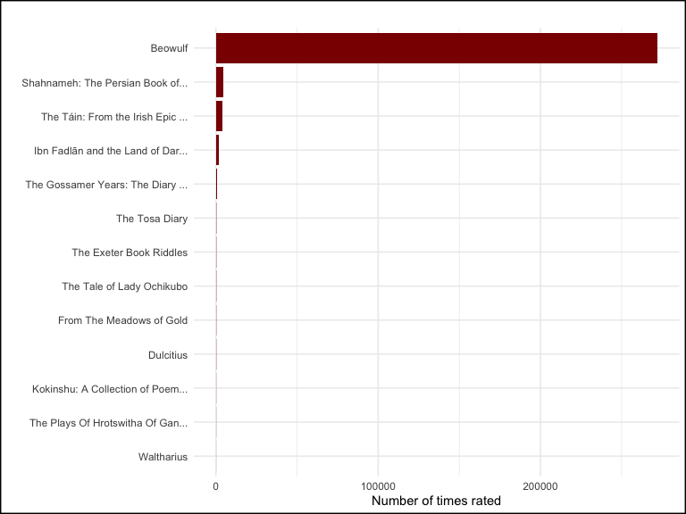

**Summary:**

- The book that was rated the most in Century 10 is **Beowulf**, and the number of votes is **272090**.
- The average number of voted for a book from Century 10 is equal **21845.5**.

### Books with the highest scores in Century 10

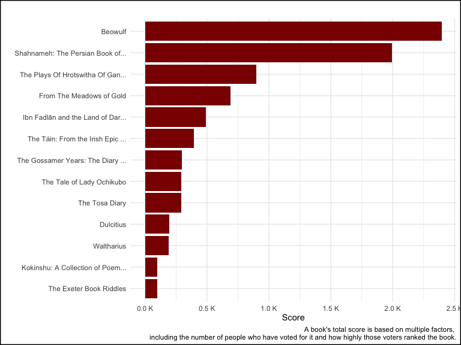

**Summary:**

- The maximum score for a book in Century 10 is **2396** for the book: **Beowulf**.
- The average score of all books in Century 10 is **640.7**.
- The minimum score for a book in Century 10 is **97** for the book: **The Exeter Book Riddles**.

### Most prolific authors in Century 10

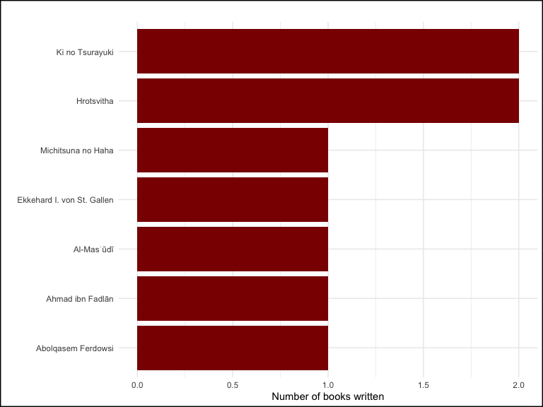

**Summary:**

## List of books with above average rating in Century 10

The number of books with the above average rating in Century 10 is **7** out of all **13** Century 10 books. The below table displays the top 10 results.

| Century | Title | Author | website |
| --- | --- | --- | --- |
| 10th | Shahnameh: The Persian Book of Kings | Abolqasem Ferdowsi | https://www.goodreads.com/book/show/157985.Shahnameh |
| 10th | From The Meadows of Gold | Al-Masʿūdī | https://www.goodreads.com/book/show/1504001.From_The_Meadows_of_Gold |
| 10th | Ibn Fadlān and the Land of Darkness: Arab Travellers in the Far North | Ahmad ibn Fadlān | https://www.goodreads.com/book/show/11038268-ibn-fadl-n-and-the-land-of-darkness |
| 10th | The Táin: From the Irish Epic Táin Bó Cúailnge | Anonymous | https://www.goodreads.com/book/show/75586.The_T_in |
| 10th | The Gossamer Years: The Diary of a Noblewoman of Heian Japan | Michitsuna no Haha | https://www.goodreads.com/book/show/186608.The_Gossamer_Years |
| 10th | Kokinshu: A Collection of Poems Ancient and Modern | Ki no Tsurayuki | https://www.goodreads.com/book/show/1178360.Kokinshu |
| 10th | The Exeter Book Riddles | Anonymous | https://www.goodreads.com/book/show/677952.The_Exeter_Book_Riddles |

### References:

https://www.goodreads.com